# STA2453 - Data Science Methods, Collaboration, and Communication

## Class #1

### September 10, 2019

Professor Nathan Taback

office: SS6027C

e-mail: nathan.taback@utoronto.ca

office hours: TBD

Course website: https://sta2453.github.io

# Course Overview

The **primary learning objectives** are:

1. to gain experience using data analysis to extract information.
2. to gain experience communicating information that arise from a data analysis.

# Computational Notebooks

Lots of users love them ...

[figure not shown]

Ref: https://github.com/parente/nbestimate

But, not everyone ...

[figure not shown]

# What is data analysis?

These quotes are from Tukey's 1962 paper, The Future of Data Analysis.

> ... data analysis, which I take to include, among other things: procedures for analyzing data, techniques for interpreting the results of such procedures, ways of planning the gathering of data to make its analysis easier, more precise or more accurate, and all the machinery and results of (mathematical) statistics which apply to analyzing data.

> Data analysis ... take on the chracteristics of a science rather than those of mathematics ...

[figure not shown]

[Roger Peng](https://leanpub.com/reportwriting) states that

> If one were to write down the steps in a data analysis, you might come up with something along these lines of the following list
> - Defining the question
> - Defining the ideal dataset
> - Determining what data you can access
> - Obtaining the data
> - Cleaning the data
> - Exploratory data analysis
> - Statistical prediction/modeling
> - Interpretation of results
> - Challenging of results
> - Synthesis and write up
> - Creating reproducible code

# Computing

- I use R and Python. RStudio and Jupyter notebooks are excellent tools.
- I expect that all work will be done in a **"reproducible"** manner.

# Data aquisition

- Experiment
- Observational study

# Data cleaning and wrangling

- Data cleaning example

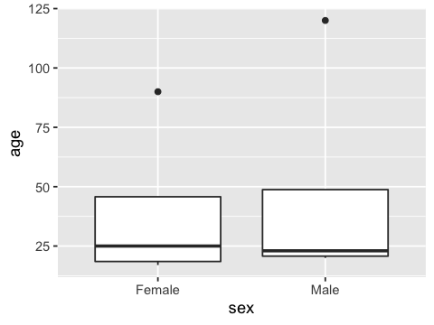

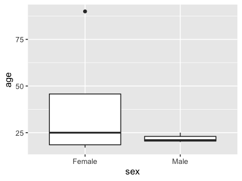

```r
library(tidyverse)
library(repr)
options(repr.plot.width=4, repr.plot.height=3)
suppressPackageStartupMessages(library(tidyverse))

agedat <- tibble(age = c(25, 20, 21, 120, 19, 31, 90, 17), sex = c(rep("Male", 4), rep("Female", 4)))
ggplot(agedat, aes(sex, age)) + geom_boxplot()
agedat_clean <- filter(agedat, age <= 100) # remove age > 100
ggplot(agedat_clean, aes(sex, age)) + geom_boxplot()
```

Go to Python notebook for Python version

# Data wrangling (transformation, etc.)

# Methods

- We will cover basic statistical (and some machine learning) methods at a very basic level.
- But,I expect that you are open to learning new statistical methods with minimal guidance.

# Data analysis - Case study

## Genetic Activity for Leukemia Patients

(Ref: CASI, pg. 8 - 10)

72 leukemia patients, 47 with ALL (acute lymphoblastic leukemia) and 25 with AML (acute myeloid leuk- emia, a worse prognosis) have each had genetic activity measured for a panel of 7,128 genes.

The data are shown below

```r
leuk_dat <- read_csv("https://web.stanford.edu/~hastie/CASI_files/DATA/leukemia_big.csv")
leuk_dat %>% head()
```

A tibble: 6 × 72

| ALL <dbl> | ALL_1 <dbl> | ALL_2 <dbl> | ALL_3 <dbl> | ALL_4 <dbl> | ALL_5 <dbl> | ALL_6 <dbl> | ALL_7 <dbl> | ALL_8 <dbl> | ALL_9 <dbl> | ⋯ | AML_15 <dbl> | AML_16 <dbl> | AML_17 <dbl> | AML_18 <dbl> | AML_19 <dbl> | AML_20 <dbl> | AML_21 <dbl> | AML_22 <dbl> | AML_23 <dbl> | AML_24 <dbl> |
| --- | --- | --- | --- | --- | --- | --- | --- | --- | --- | --- | --- | --- | --- | --- | --- | --- | --- | --- | --- | --- |
| -1.5336217 | -0.8676096 | -0.4331719 | -1.6719032 | -1.1876894 | -1.1272336 | -1.0454091 | -0.1069170 | -1.1987957 | -1.1908987 | ⋯ | -0.43665029 | -1.27470781 | -0.68145848 | -0.8766099 | -0.6240218 | -0.4316276 | -1.4352588 | -0.6719538 | -1.0131609 | -0.9694822 |
| -1.2356729 | -1.2755005 | -1.1844922 | -1.5964240 | -1.3352557 | -1.1137304 | -0.8008802 | -0.7451766 | -0.8493121 | -1.1908987 | ⋯ | -0.91548270 | -1.35436266 | -0.65355897 | -1.0962496 | -1.0665942 | -1.3352557 | -1.2045864 | -0.7514571 | -0.8895921 | -1.0809876 |
| -0.3339829 | 0.3759265 | -0.4591960 | -1.4225714 | -0.7974929 | -1.3627683 | -0.6719538 | -1.1756743 | 0.3208134 | 0.6466095 | ⋯ | -0.73615632 | -0.02215325 | -0.03745523 | -0.5673348 | -1.1007494 | -0.5529381 | -0.9488738 | -0.2316568 | -0.7421631 | -0.7795000 |
| 0.4887021 | 0.4440110 | 0.4362635 | 0.1933529 | 0.2356315 | -0.3603116 | 0.1849409 | 0.4256533 | 0.3339829 | 0.2352700 | ⋯ | 0.08378111 | 0.35656224 | 0.41624076 | 0.5339862 | 0.2275053 | 0.4168160 | 0.4082022 | 0.3265565 | 0.3618128 | 0.2988635 |
| -1.3008933 | -1.2296598 | -1.3258824 | -1.8183288 | -1.3112060 | -1.5139747 | -1.6516236 | -1.3395553 | -0.5931317 | 0.1333023 | ⋯ | -1.54744405 | -1.26447453 | -1.51231763 | -1.4695825 | -1.2834722 | -0.9776716 | -1.0901780 | -1.5451198 | -1.1742718 | -1.4431827 |
| -1.6826682 | -1.6420718 | -1.4072639 | -1.7444693 | -1.6543805 | -1.7776193 | -1.8056201 | -1.7078182 | -1.7033012 | -1.0466244 | ⋯ | -1.70180325 | -1.83891357 | -1.58768329 | -1.7493204 | -1.6826682 | -1.4706185 | -1.4858212 | -1.7616315 | -1.5790622 | -1.6366803 |

The histograms and boxplots below show the distributions for gene 48 in the ALL and AML groups.

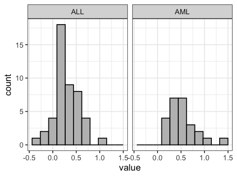

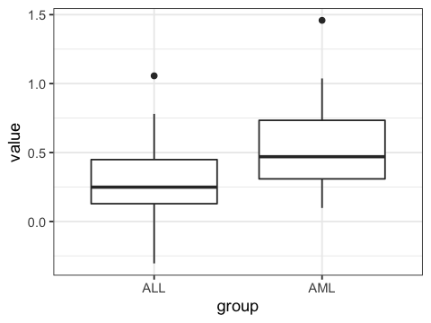

# Exercise #1

Create the histogram and boxplots above using R or Python. Interpret each plot. Which plot do you prefer to compare the distributions? Why?

Is there a difference in gene 48 between patients with `ALL` (acute lymphoblastic leukemia) compared to `AML`(acute myeloid leukemia, a worse prognosis)?

A tibble: 1 × 9

| estimate1 <dbl> | estimate2 <dbl> | statistic <dbl> | p.value <dbl> | parameter <dbl> | conf.low <dbl> | conf.high <dbl> | method <chr> | alternative <chr> |
| --- | --- | --- | --- | --- | --- | --- | --- | --- |
| 0.3038753 | 0.5307917 | -3.304723 | 0.001501085 | 70 | -0.363863 | -0.08996983 | Two Sample t-test | two.sided |

# Exercise #2

Use R or Python to calculate a p-value for a test comparing the two groups. Interpret the p-value.

This is one candidate gene out of 7,128 genes. Is $t=-3.30$ unusual?

A tibble: 1 × 3

| n <int> | count <int> | percent <dbl> |
| --- | --- | --- |
| 7128 | 346 | 4.85 |

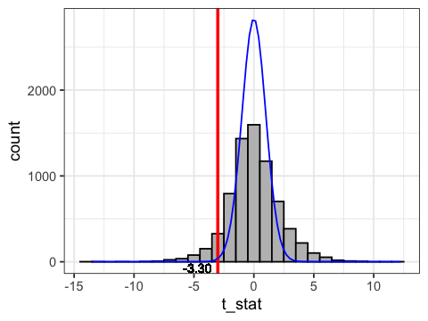

# Exercise #3

Create the histogram above using R or Python. Write a few sentences describing how the histogram above was generated. Is gene48 unusual compared to other genes?

# Statistical Thinking and Hypothesis Testing

- The general ideas behind testing hypotheses permeate "statistical thinking".
- The core of statistical thinking includes the appreciation of uncertaintity and variability.
- Hospital A has 20 births per day and Hospital B has 50 births per day. During a period one year which hospital is more likely to have more than 60% boys born?

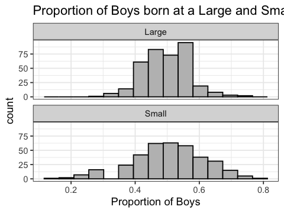

# Exercise #4

During a period two years which hospital is more likely to have more than 60% boys born? Use R or Python to create similar histograms that show the distributions of boys in a large and small hospital.

## Hypothesis Testing

- Let's look at the expression of gene 48 between the two groups, ALL and AML.
- Assume that there is **no difference** in gene expression between the two groups. This means that the same gene expression value for a patient would occur if that patient is in the ALL or AML groups.

```r
set.seed(100)
gene_48 %>% select(value, group) %>% sample_n(5)

gene_48 %>% group_by(group) %>%
  summarise(n = n(), mean = mean(value), sd = sd(value))  %>%
  mutate(diff = mean - lag(mean))
```

A tibble: 5 × 2

| value <dbl> | group <chr> |
| --- | --- |
| 0.7433214 | AML |
| 0.5228681 | AML |
| 0.4015234 | ALL |
| -0.1060330 | ALL |
| 0.2423247 | ALL |

A tibble: 2 × 5

| group <chr> | n <int> | mean <dbl> | sd <dbl> | diff <dbl> |
| --- | --- | --- | --- | --- |
| ALL | 47 | 0.3038753 | 0.2574523 | NA |
| AML | 25 | 0.5307917 | 0.3120515 | 0.2269164 |

A tibble: 1 × 1

| pvalu <dbl> |
| --- |
| 5e-04 |

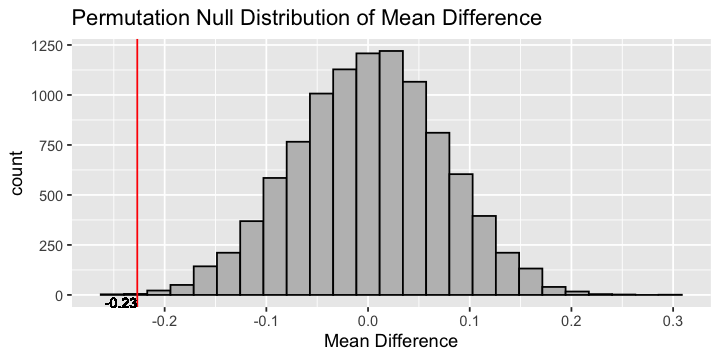

```r
options(repr.plot.width=6, repr.plot.height=3)
tibble(rs_dist) %>%
  ggplot(aes(rs_dist)) + geom_histogram(colour = "black", fill = "grey", bins = 25) +
  geom_vline(xintercept = -0.2269164, colour = "red") +
  ggtitle("Permutation Null Distribution of Mean Difference") + xlab("Mean Difference") +
  geom_text(aes(-0.2269164, 0, label = "-0.23", hjust = 1, vjust = 1.2), size = 3)


tibble(rs_dist) %>% summarise(pvalu = sum(rs_dist <= -0.2269164)/Numsim)
```

# Exercise #5

Use R or Python to create the permutation distribution. Calculate the two-sided P-value? Briefly interpret the two-sided P-value.